# Project 2 Long Term Deposits

Ryan Bass, Brett Benefield

April 17, 2018

#### Data Set: https://archive.ics.uci.edu/ml/datasets/bank+marketing

#### Source: [Moro et al., 2014] S. Moro, P. Cortez and P. Rita. A Data-Driven Approach to Predict the Success of Bank Telemarketing. Decision Support Systems, Elsevier, 62:22-31, June 2014

# Long Term Deposit Prediction

# Executive Summary

The purpose of this data set is to predict whether a client will subscribe to a long term deposit (CD). The data was collected from a Portuguese banking institute which conducted a marketing campaign through phone calls.

# Introduction

Using variables such age, marital status, education, job, duration of the call, we attempted to classify whether a client would sign up for a long term deposit. After initial exploration of the data through plots and graphs we used a random forest model, logistic regression model, and a simplified regression model to aid in this classification.

### Intial exploratory plot of age, balance, and the Term Deposit result overlaid

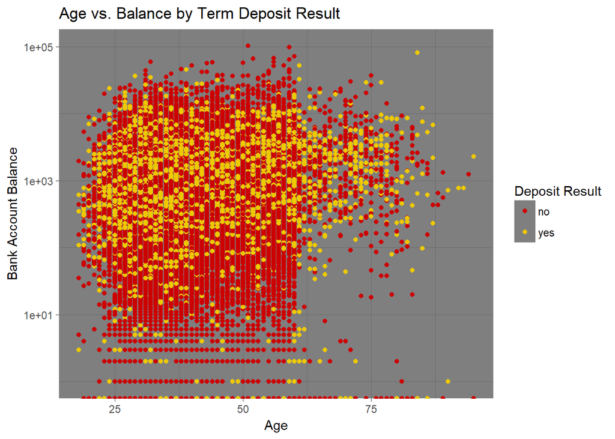

#### NOTE: the abrubt lack of people contacted from the bank that are older than 60. Also “yes” seems more prevalent % wise in the greater than 60’s and balances above $10.

### Histogram of age distribution, and the term deposit result overlaid

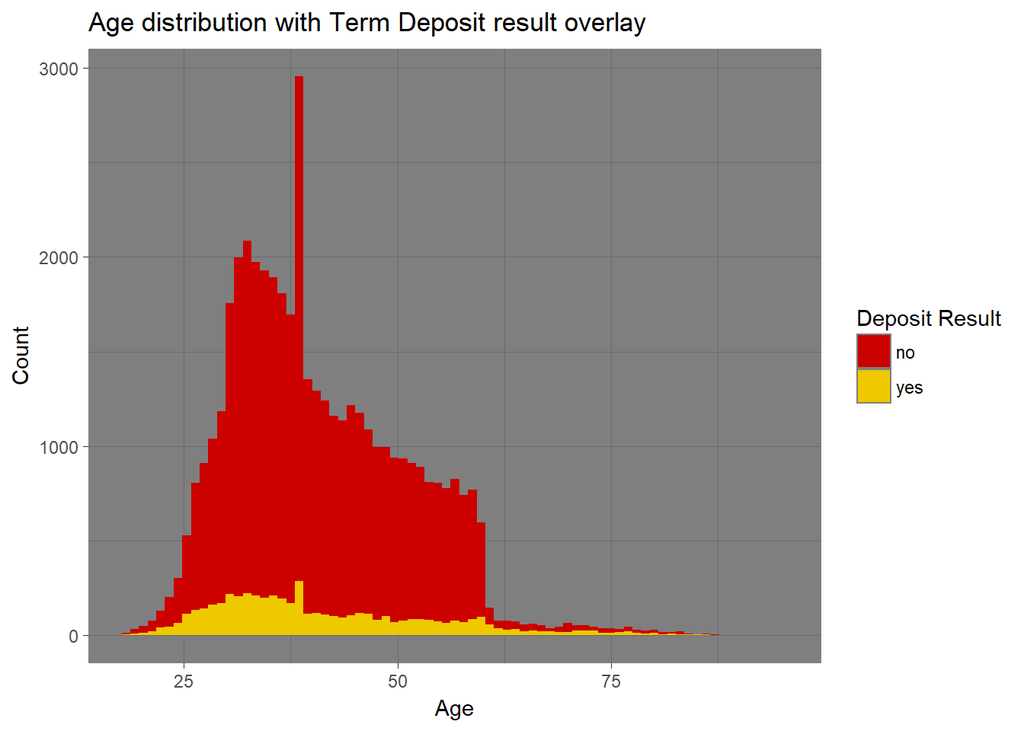

#### NOTE: Can see while majority of the ages are in their late 20’s and early 30’s, the older the customers are the higher % they are to start a term deposit

### Yes to term deposit by decade age ranges

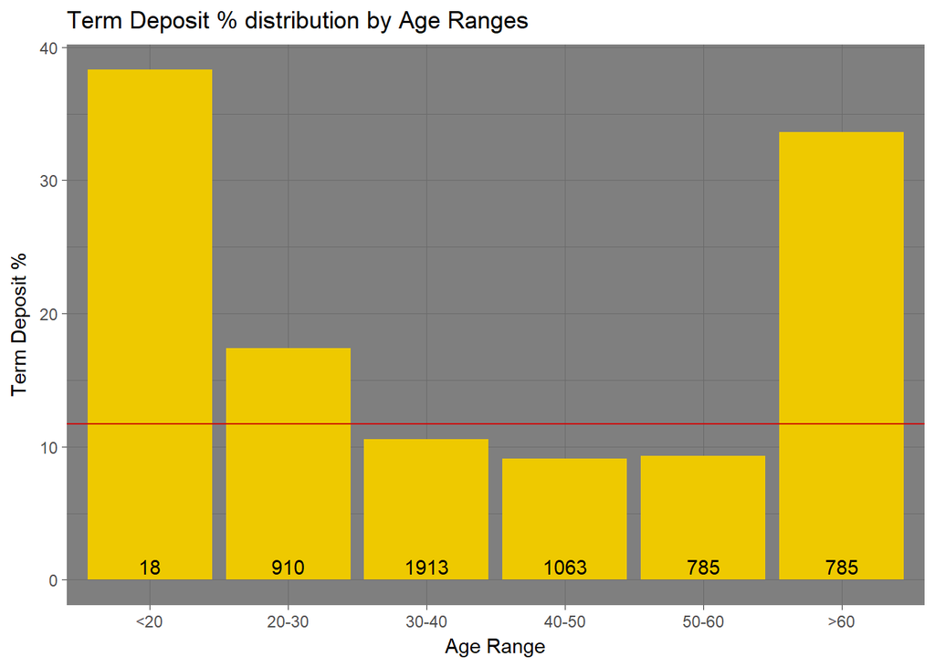

#### NOTE: Can see the youngest and oldest age ranges are the highest to agree to a Term Deposit. need to put n’s and error bars on this though

### Plotting of the % who started a Term Deposit by their education level

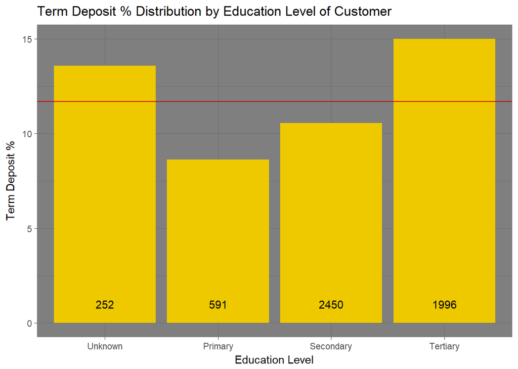

### Bar graph of the percent who enrolled in Term Deposit per job type (and their total counts)

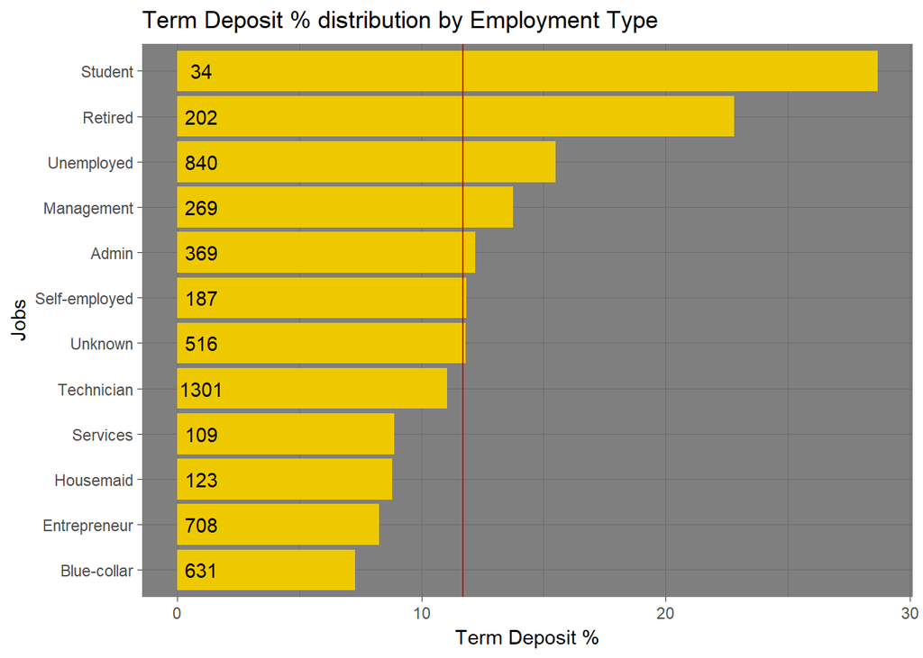

### Term Deposit % distribution by Marital Status

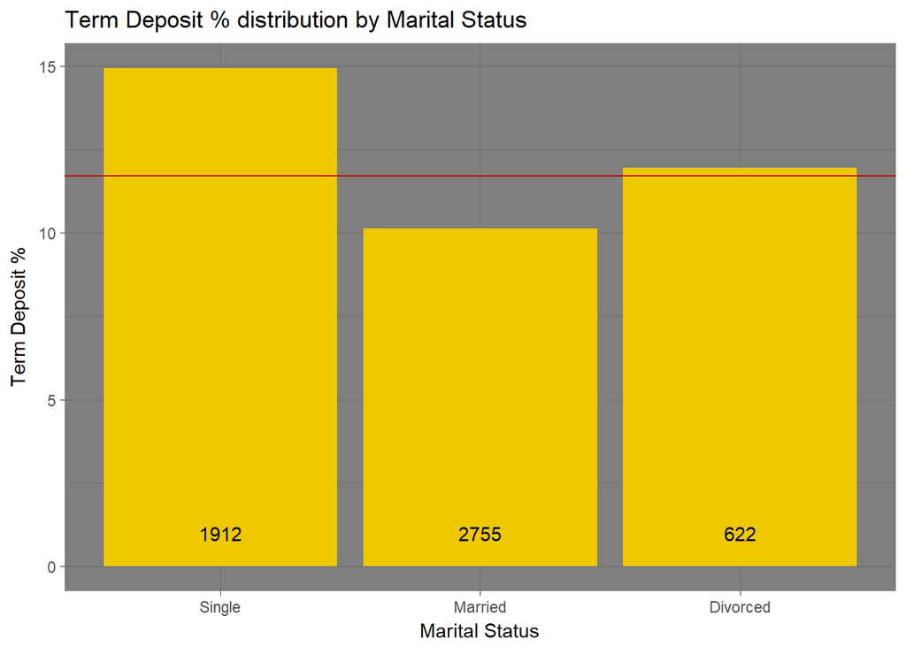

### Plotting of the % who started a Term Deposit in a given month contact was made

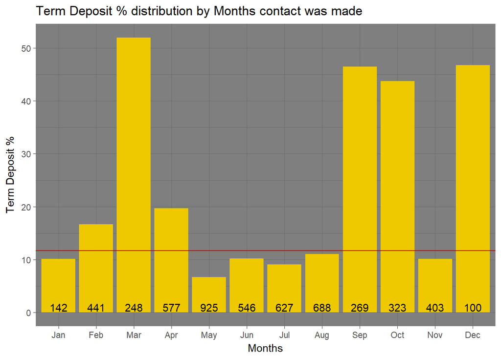

#### NOTE: March, September, October, and December for whatever reason are far above the others.

### Contact duration vs. term deposit box plot

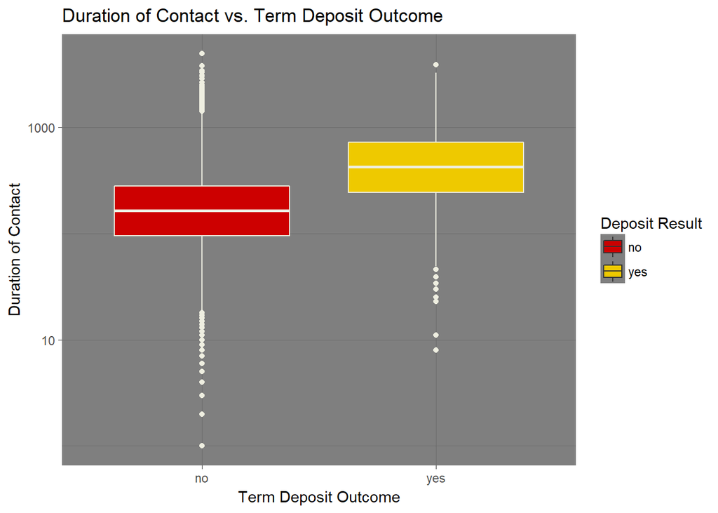

### Duration related to term deposit and contact type

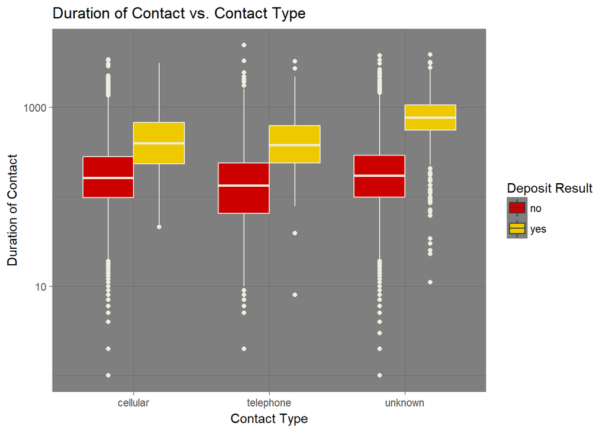

# Random Forest Model

#### Error Rate ~ 9%

```
##
## Call:
##  randomForest(formula = as.factor(y) ~ ., data = train, importance = TRUE,      ntree = 100)
##                Type of random forest: classification
##                      Number of trees: 100
## No. of variables tried at each split: 4
##
##         OOB estimate of  error rate: 9.29%
## Confusion matrix:
##        no  yes class.error
## no  28820 1114  0.03721521
## yes  2037 1938  0.51245283
```

### Explanatory variable importance

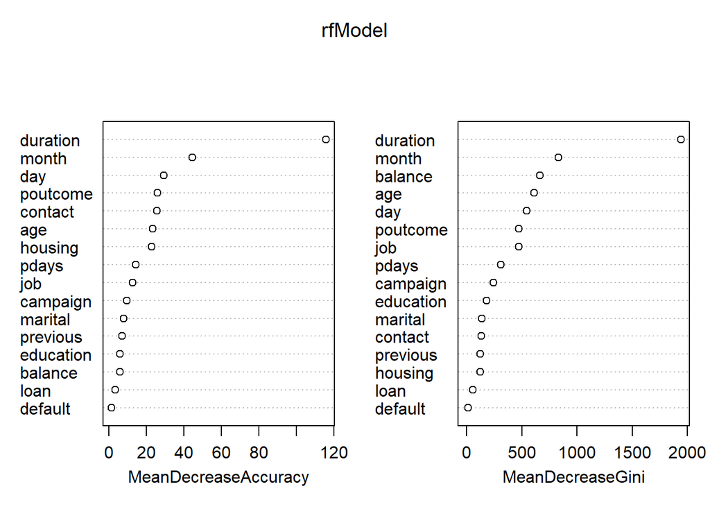

### Number of Trees vs Error Rate

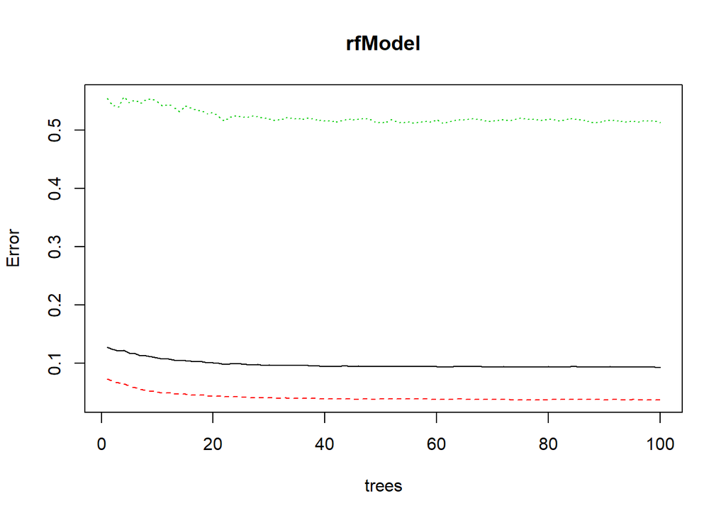

### ROC Curve

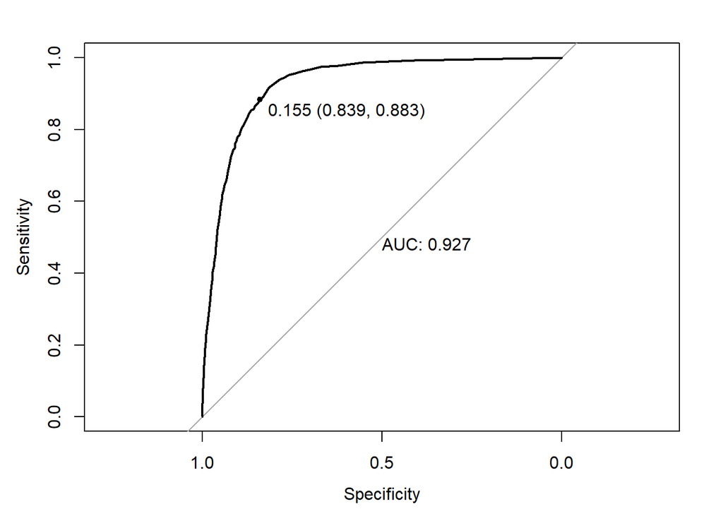

# Logistic Regression Model

### ROC curve

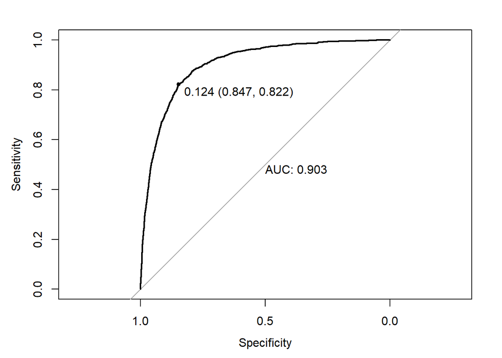

### Confusion Matrix

#### Error Rate ~ 10%

```
##                actualValues
## predictedValues    no   yes
##               0 29178  2588
##               1   756  1387
```

# Simplified Logistic Regression Model

### ROC Curve

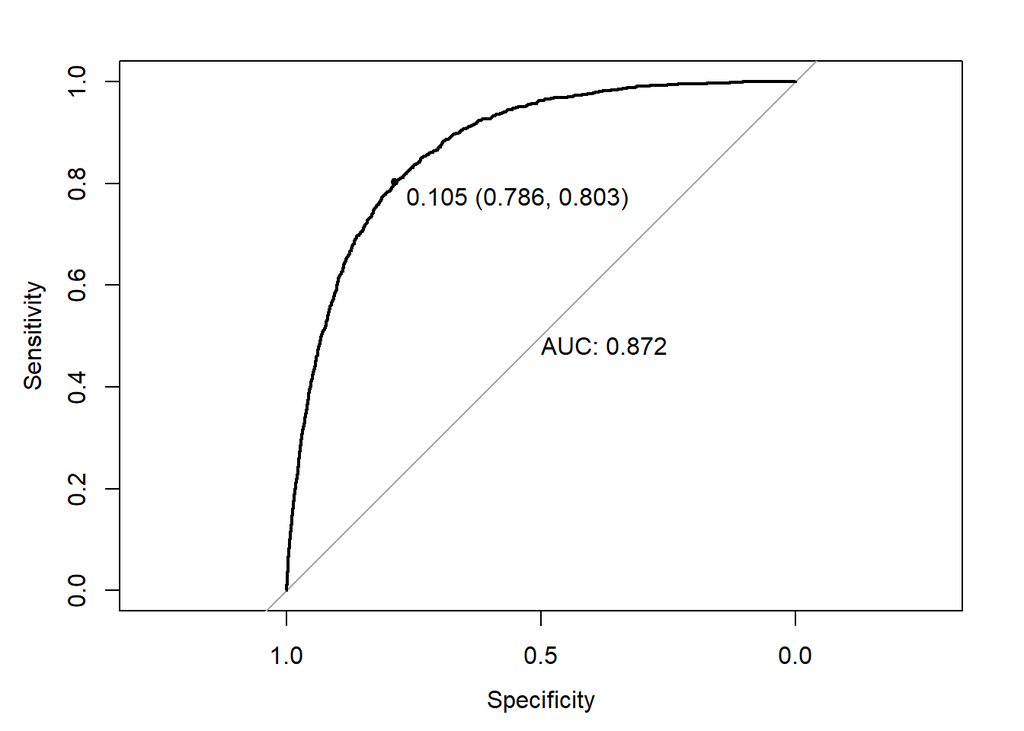

### Confusion Matrix

#### Error Rate ~ 11%

```
##                actualValues
## predictedValues    no   yes
##               0 29293  3021
##               1   641   954
```

### Odds

```
##        (Intercept)           duration           monthaug
##         0.05967165         1.00386625         0.55780913
##           monthdec           monthfeb           monthjan
##         3.05816096         0.90765756         0.39680203
##           monthjul           monthjun           monthmar
##         0.37667900         0.51860148         5.59614172
##           monthmay           monthnov           monthoct
##         0.28847685         0.48205732         3.51135534
##           monthsep     jobblue-collar    jobentrepreneur
##         3.70131456         0.64397886         0.56544500
##       jobhousemaid      jobmanagement         jobretired
##         0.72537344         0.81424741         1.72973094
##   jobself-employed        jobservices         jobstudent
##         0.76301266         0.71417414         2.12948713
##      jobtechnician      jobunemployed         jobunknown
##         0.81350795         0.93825715         0.86564433
## educationsecondary  educationtertiary   educationunknown
##         1.19623108         1.71582386         1.37808997
##     maritalmarried      maritalsingle
##         0.83810957         1.23319348
```

# Probability Exploration